# 個人VTuber分析レポート

まる

2024年5月27日

# 1 各特徴量ごとの活動人数

## 1.1 性別

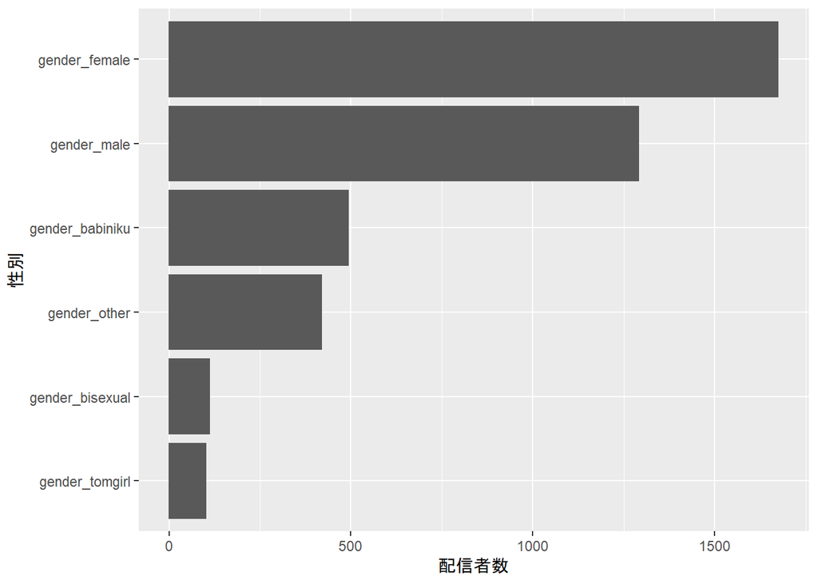

```r
data_gender %>%
  pivot_longer(
    cols = -"channelId",
    names_to = "feature"
  ) %>%
  ggplot(
    aes(
      x = feature %>% reorder(value),
      y = value
    )
  ) +
  geom_bar(stat="identity") +
  xlab("性別") +
  ylab("配信者数")+
  coord_flip()
```

## 1.2 モデル

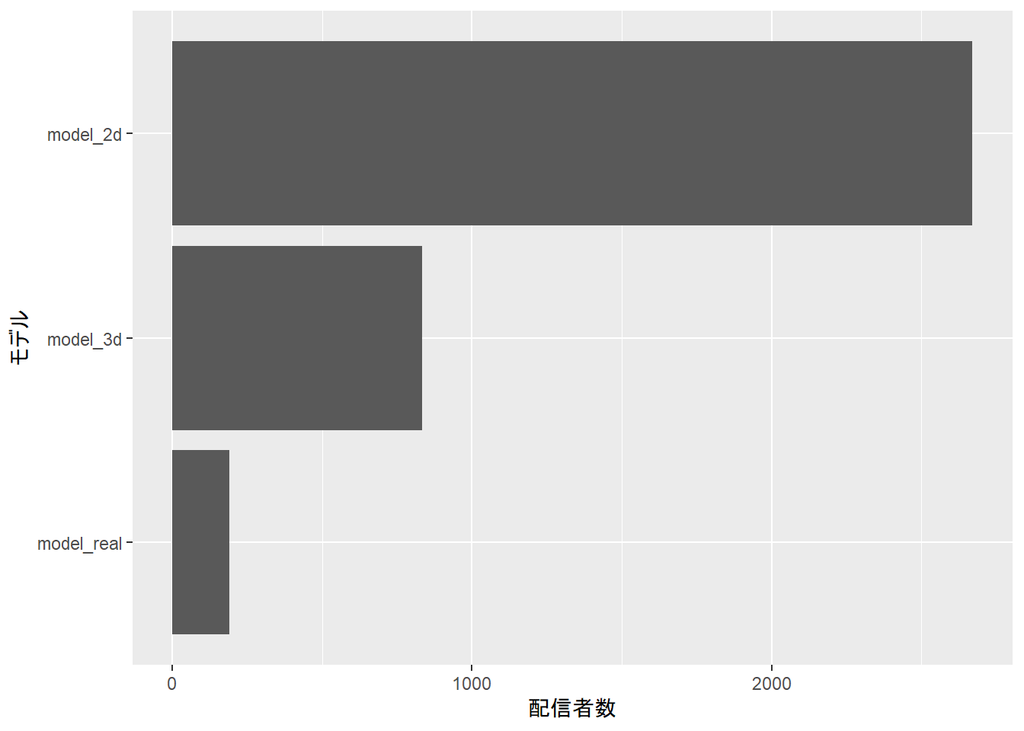

```r
data_model %>%
  pivot_longer(
    cols = -"channelId",
    names_to = "feature"
  ) %>%
  ggplot(
    aes(
      x = feature %>% reorder(value),
      y = value
    )
  ) +
  geom_bar(stat="identity") +
  xlab("モデル") +
  ylab("配信者数") +
  coord_flip()
```

## 1.3 ジャンル

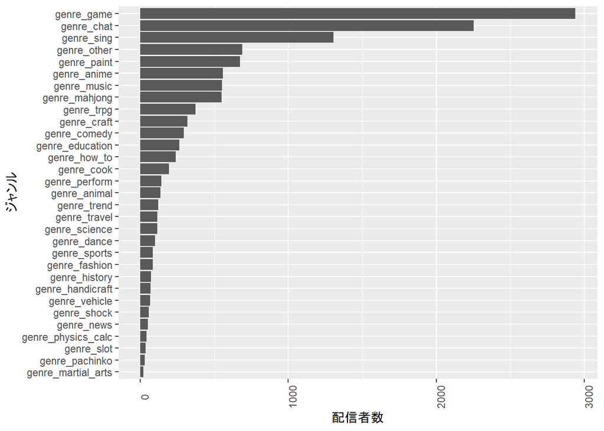

```r
data_genre %>%
  pivot_longer(
    cols = -"channelId",
    names_to = "feature"
  ) %>%
  ggplot(
    aes(
      x = feature %>% reorder(value),
      y = value
    )
  ) +
  geom_bar(stat="identity") +
  theme(
    axis.text.x = element_text(angle = 90)
  ) +
  xlab("ジャンル") +
  ylab("配信者数")+
  coord_flip()
```

## 1.4 得意なこと

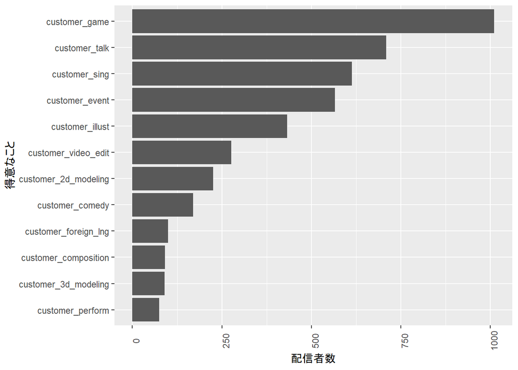

```r
data_customer %>%
  pivot_longer(
    cols = -"channelId",
    names_to = "feature"
  ) %>%
  ggplot(
    aes(
      x = feature %>% reorder(value),
      y = value
    )
  ) +
  geom_bar(stat="identity") +
  theme(
    axis.text.x = element_text(angle = 90)
  ) +
  xlab("得意なこと") +
  ylab("配信者数")+
  coord_flip()
```

## コラボ希望度

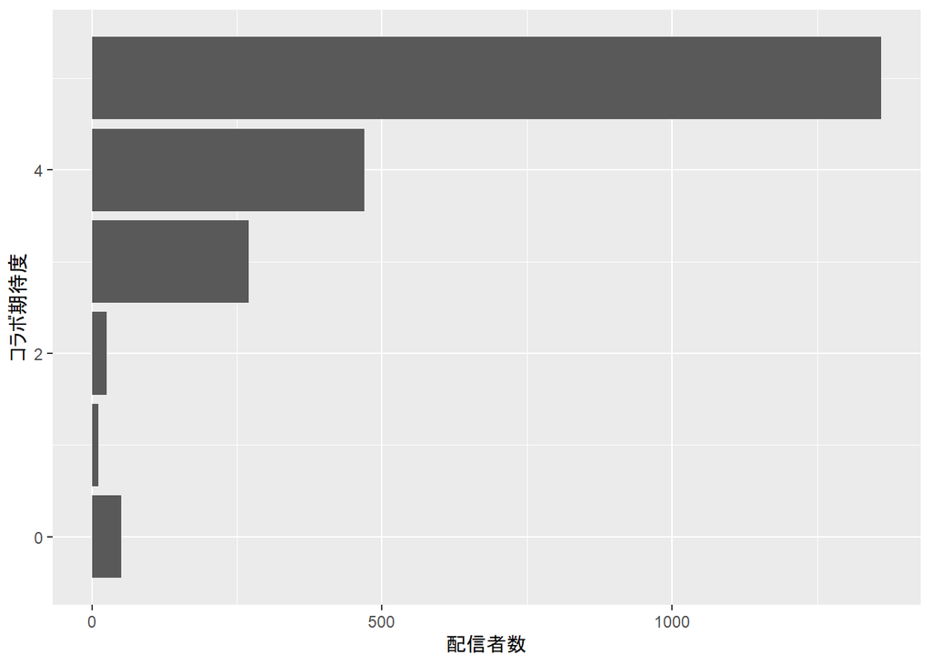

```r
data_collabo %>%
  ggplot(
    aes(
      x = collabo_level
    )
  ) +
  geom_bar(stat="count") +
  xlab("コラボ期待度") +
  ylab("配信者数") +
  coord_flip()
```

# 2 各特徴ごとのチャンネル登録者数

```r
## subscriberCountを対数変換したデータフレームを用意
data_livers_log <-
  data_livers %>%
  filter(subscriberCount >=100) %>%
  mutate(log_subscriberCount = subscriberCount %>% log(10)) %>%
  select(channelId, log_subscriberCount)
```

## 2.1 性別

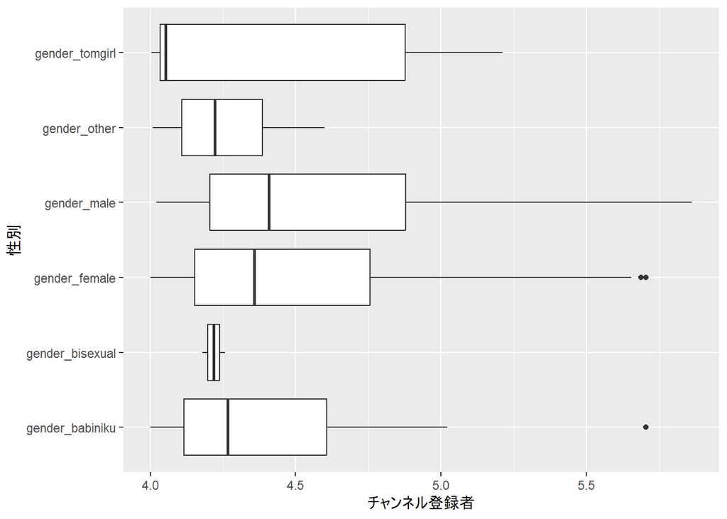

```r
### 対数変換後
data_livers_log %>%
  inner_join(data_gender, by="channelId") %>%
  select(-channelId) %>%
  pivot_longer(-log_subscriberCount, names_to = "gender") %>%
  filter(value==1) %>%
  ggplot(
    aes(
      x = gender,
      y = log_subscriberCount
    )
  ) +
  geom_boxplot() +
  xlab("性別") +
  ylab("チャンネル登録者")+
  coord_flip()
```

## 2.2 チャンネル登録者に男女差はあるか

```r
### 対数変換後
data_test1 <-
  data_livers_log %>%
  inner_join(data_gender, by="channelId") %>%
  select(-channelId) %>%
  pivot_longer(-log_subscriberCount, names_to = "gender") %>%
  filter(value==1)

t.test(
  data_test1 %>% filter(gender=="gender_male") %>% select(log_subscriberCount),
  data_test1 %>% filter(gender=="gender_female") %>% select(log_subscriberCount),
  var.equal=F,
  paired=F
)
```

```
##
##  Welch Two Sample t-test
##
## data:  data_test1 %>% filter(gender == "gender_male") %>% select(log_subscriberCount) and data_test1 %>% filter(gender == "gender_female") %>% select(log_subscriberCount)
## t = 1.0946, df = 82.684, p-value = 0.2769
## alternative hypothesis: true difference in means is not equal to 0
## 95 percent confidence interval:
##  -0.06272547  0.21623877
## sample estimates:
## mean of x mean of y
##  4.582286  4.505529
```

```r
data_test1 <-
  data_livers_log %>%
  inner_join(data_gender, by="channelId") %>%
  select(-channelId) %>%
  pivot_longer(-log_subscriberCount, names_to = "gender") %>%
  filter(value==1)

### 男性V vs 女性V
t.test(
  data_test1 %>% filter(gender=="gender_male") %>% select(log_subscriberCount),
  data_test1 %>% filter(gender=="gender_female") %>% select(log_subscriberCount),
  var.equal=F,
  paired=F
)
```

```
##
##  Welch Two Sample t-test
##
## data:  data_test1 %>% filter(gender == "gender_male") %>% select(log_subscriberCount) and data_test1 %>% filter(gender == "gender_female") %>% select(log_subscriberCount)
## t = 1.0946, df = 82.684, p-value = 0.2769
## alternative hypothesis: true difference in means is not equal to 0
## 95 percent confidence interval:
##  -0.06272547  0.21623877
## sample estimates:
## mean of x mean of y
##  4.582286  4.505529
```

```r
### 男性V vs バ美肉
t.test(
  data_test1 %>% filter(gender=="gender_male") %>% select(log_subscriberCount),
  data_test1 %>% filter(gender=="gender_babiniku") %>% select(log_subscriberCount),
  var.equal=F,
  paired=F
)
```

```
##
##  Welch Two Sample t-test
##
## data:  data_test1 %>% filter(gender == "gender_male") %>% select(log_subscriberCount) and data_test1 %>% filter(gender == "gender_babiniku") %>% select(log_subscriberCount)
## t = 1.2997, df = 33.779, p-value = 0.2025
## alternative hypothesis: true difference in means is not equal to 0
## 95 percent confidence interval:
##  -0.08746082  0.39763117
## sample estimates:
## mean of x mean of y
##  4.582286  4.427201
```

# 3 ジャンルのクラスタ分け

## 3.1 最適なクラスタ数を決める

### 3.1.1 BIC

```r
kmeansAIC <- function(fit){

  m <- ncol(fit$centers)
  n <- length(fit$cluster)
  k <- nrow(fit$centers)
  D <- fit$tot.withinss
  return(data.frame(AIC = D + 2*m*k,
                    BIC = D + log(n)*m*k))
}

d <- data_genre %>% select(starts_with("genre"))
res <- c()
for (i in 2:15){
  fit <- kmeans(d, i)
  tmp <- kmeansAIC(fit)
  res <- rbind(res, cbind(tmp, i))
}
print(res)
```

```
##         AIC      BIC  i
## 1  7384.290 7776.082  2
## 2  6871.977 7459.666  3
## 3  6648.848 7432.433  4
## 4  6442.363 7421.843  5
## 5  6363.574 7538.950  6
## 6  6243.521 7614.794  7
## 7  5911.059 7478.228  8
## 8  6126.023 7889.088  9
## 9  5907.054 7866.015 10
## 10 6043.148 8198.006 11
## 11 5803.406 8154.160 12
## 12 5750.179 8296.828 13
## 13 5731.911 8474.457 14
## 14 5776.627 8715.069 15
```

### 3.1.2 エルボー図

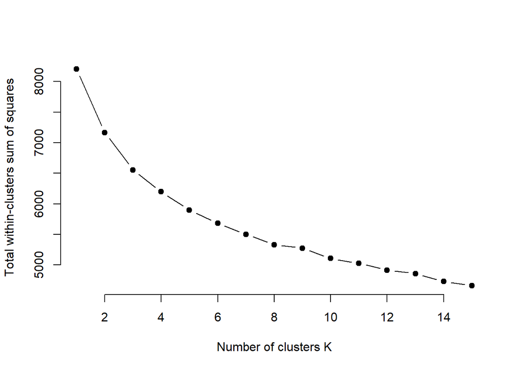

```r
k.max <- 15
wss <- sapply(1:k.max,
              function(k){kmeans(d, k, nstart = 50, iter.max = 15)$tot.withinss})
plot(1:k.max, wss,
     type="b", pch = 19, frame = FALSE,
     xlab="Number of clusters K",
     ylab="Total within-clusters sum of squares")
```

### 3.1.3 階層クラスター分析

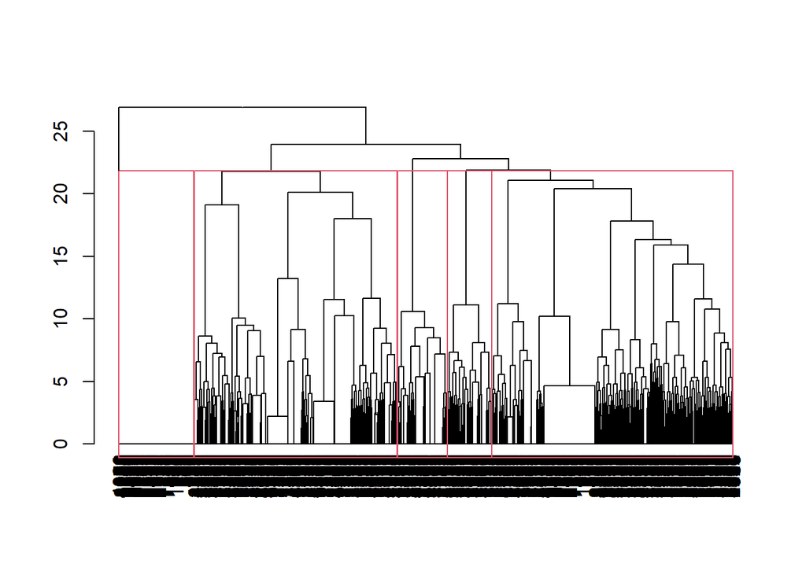

```r
result <- hclust(dist(d), method = "ward.D2")
plot(as.dendrogram(result))
rect.hclust(result, k = 5)
```

## 3.2 クラスタリングの実施

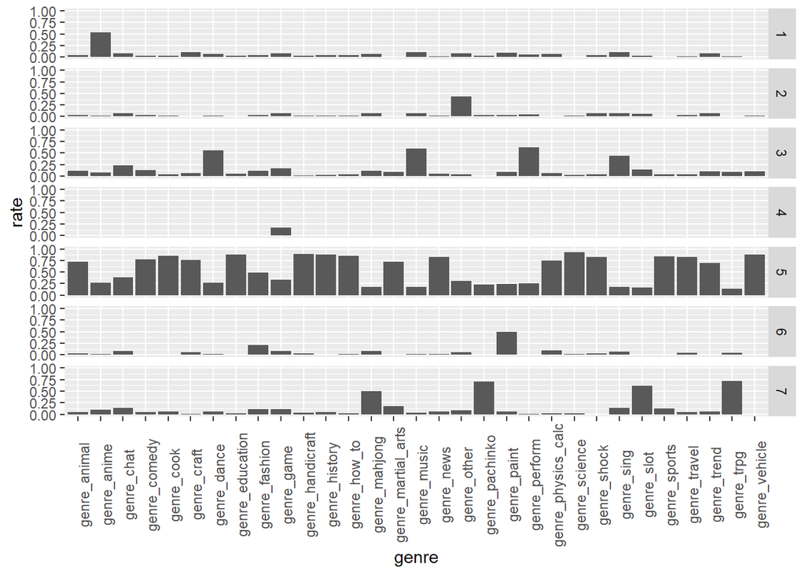

```r
cluster = cutree(result, k=7)
len = length(cluster)

data_genre_count <-
  data_genre %>%
  pivot_longer(
    cols     = -channelId,
    names_to = "genre"
  ) %>%
  select(-channelId) %>%
  group_by(genre) %>%
  summarize(count=sum(value))

data_genre %>%
  select(starts_with("genre")) %>%
  mutate(cluster = cluster) %>%
  pivot_longer(
    cols = -cluster,
    names_to = "genre"
  ) %>%
  inner_join(
    data_genre_count,
    by = "genre"
  ) %>%
  group_by(cluster, genre) %>%
  summarize(weight=sum(value/count),n = n()) %>%
  mutate(rate = weight) %>%
  ggplot(
    aes(
      x = genre,
      y = rate
    )
  ) +
  geom_bar(stat="identity") +
  theme(
    axis.text.x = element_text(angle = 90)
  ) +
  facet_grid(
    cluster ~ .
  ) +
  ylim(0,1)
```

### 3.2.1 結果の解釈

- k = 7
  - オールジャンル
  - ゲーム特化
  - 音楽
  - お絵かき
  - アニメ
  - ギャンブル・TRPG
  - その他に特化

# 4 ジャンルクラスタの解析

## 4.1 各ジャンルの活動者数

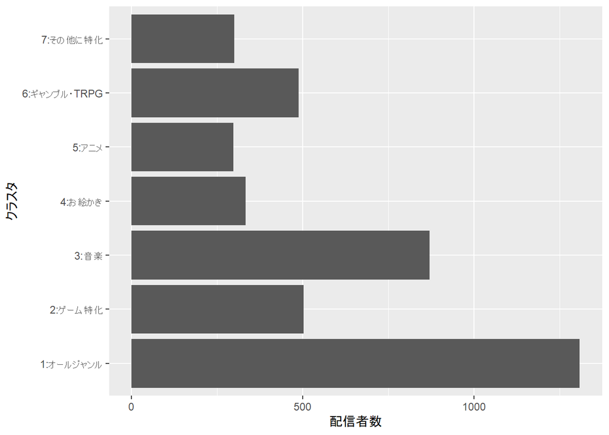

```r
data_genre_cluster %>%
  ggplot(
    aes(
      x = cluster
    )
  ) +
  geom_bar(stat="count") +
  xlab("クラスタ") +
  ylab("配信者数") +
  coord_flip()
```

## 4.2 各ジャンルごとのチャンネル登録者数

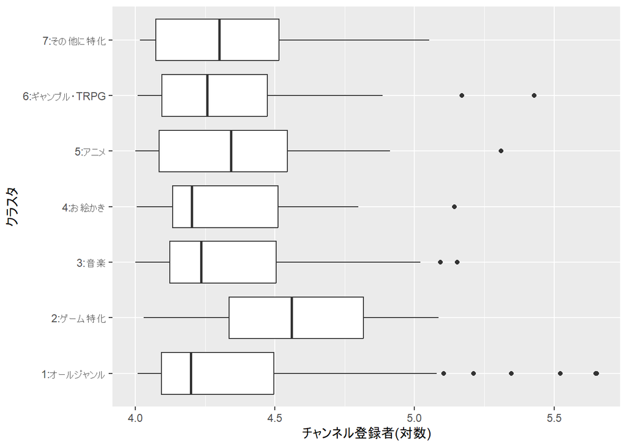

```r
data_livers %>%
  inner_join(data_genre_cluster, by="channelId") %>%
  ggplot(
    aes(
      x = cluster,
      y = subscriberCount %>% log10
    )
  ) +
  geom_boxplot() +
  xlab("クラスタ") +
  ylab("チャンネル登録者(対数)")+
  coord_flip()
```

### 4.2.1 活動ジャンルはチャンネル登録者に影響を与えるか

```r
data_test <-
  data_livers %>%
  inner_join(data_genre_cluster, by="channelId")

pairwise.t.test(
  data_test$subscriberCount %>% log10,
  data_test$cluster,
  p.adj = "bonf"
)
```

```
##
##  Pairwise comparisons using t tests with pooled SD
##
## data:  data_test$subscriberCount %>% log10 and data_test$cluster
##
##                    1:オールジャンル 2:ゲーム特化 3:音楽 4:お絵かき 5:アニメ
## 2:ゲーム特化       1.00             -            -      -          -
## 3:音楽             1.00             0.55         -      -          -
## 4:お絵かき         1.00             1.00         1.00   -          -
## 5:アニメ           1.00             1.00         1.00   1.00       -
## 6:ギャンブル・TRPG 1.00             1.00         1.00   1.00       1.00
## 7:その他に特化     1.00             1.00         1.00   1.00       1.00
##                    6:ギャンブル・TRPG
## 2:ゲーム特化       -
## 3:音楽             -
## 4:お絵かき         -
## 5:アニメ           -
## 6:ギャンブル・TRPG -
## 7:その他に特化     1.00
##
## P value adjustment method: bonferroni
```

## 4.3 各ジャンルごとのコラボ希望度

### 4.3.1 コラボ「5」登録率

[output not shown]

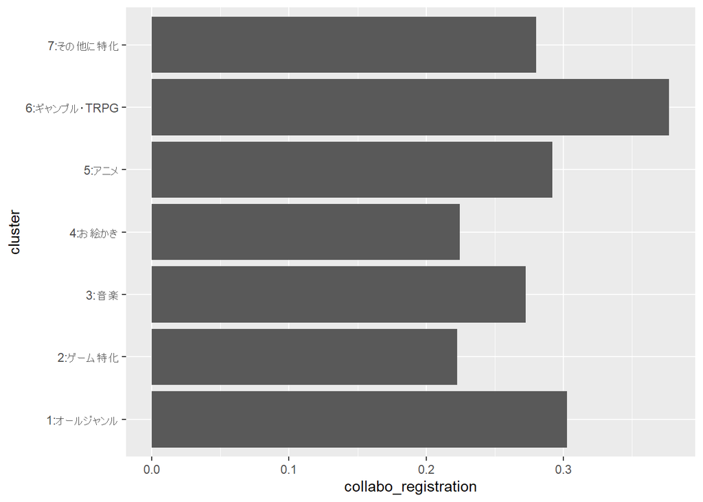

```r
data_genre_cluster %>%
  left_join(data_collabo, by="channelId") %>%
  mutate(collabo_registration = ifelse(is.na(collabo_level)|(collabo_level<=4),0,1)) %>%
  select(cluster, collabo_registration) %>%
  group_by(cluster) %>%
  summarise(collabo_registration=mean(collabo_registration)) %>%
  ggplot(
    aes(
      x = cluster,
      y = collabo_registration
    )
  ) +
  geom_bar(stat="identity") +
  coord_flip()+
  coord_flip()
```

- ゲーム特化・お絵描きクラスタはコラボをしにくい
- ギャンブル・TRPGクラスタはコラボに寛容

# 5 得意なことのクラスタ分け

## 5.1 最適なクラスタ数を決める

### 5.1.1 BIC

```r
kmeansAIC <- function(fit){

  m <- ncol(fit$centers)
  n <- length(fit$cluster)
  k <- nrow(fit$centers)
  D <- fit$tot.withinss
  return(data.frame(AIC = D + 2*m*k,
                    BIC = D + log(n)*m*k))
}

d <- data_customer %>% select(starts_with("customer"))
res <- c()
for (i in 2:15){
  fit <- kmeans(d, i)
  tmp <- kmeansAIC(fit)
  res <- rbind(res, cbind(tmp, i))
}
print(res)
```

```
##         AIC      BIC  i
## 1  2499.055 2629.350  2
## 2  2236.287 2431.728  3
## 3  2187.952 2448.540  4
## 4  1974.327 2300.062  5
## 5  1911.685 2302.567  6
## 6  1801.141 2257.171  7
## 7  1815.947 2337.124  8
## 8  1677.140 2263.464  9
## 9  1787.686 2439.158 10
## 10 1722.979 2439.597 11
## 11 1641.280 2423.046 12
## 12 1771.808 2618.720 13
## 13 1651.902 2563.962 14
## 14 1662.678 2639.885 15
```

### 5.1.2 階層クラスター分析

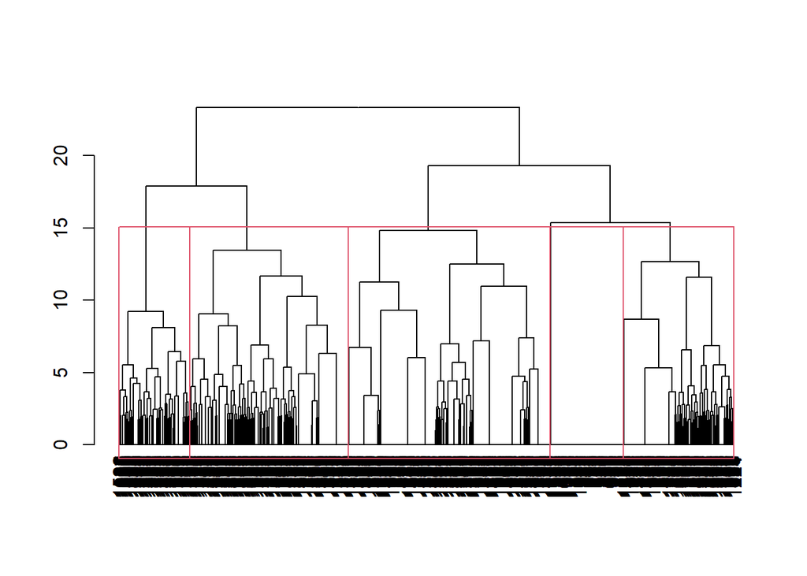

```r
result <- hclust(dist(d), method = "ward.D2")
plot(as.dendrogram(result))
rect.hclust(result, k = 5)
```

## 5.2 クラスタリングの実施

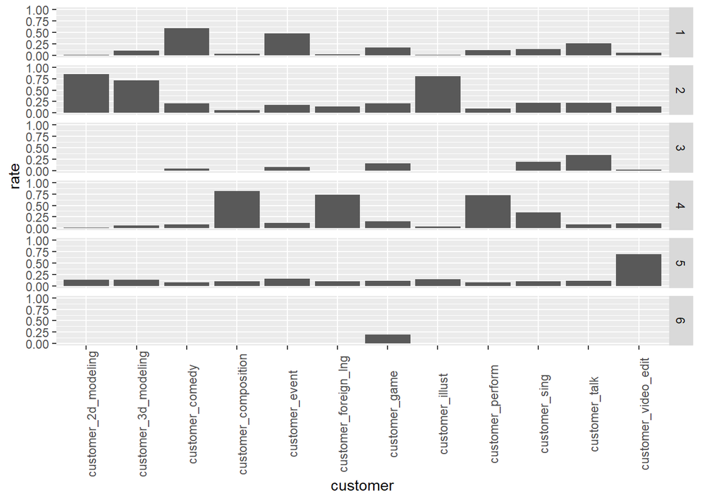

```r
cluster = cutree(result, k=6)
len = length(cluster)

data_customer_count <-
  data_customer %>%
  pivot_longer(
    cols     = -channelId,
    names_to = "customer"
  ) %>%
  select(-channelId) %>%
  group_by(customer) %>%
  summarize(count=sum(value))

data_customer %>%
  select(starts_with("customer")) %>%
  mutate(cluster = cluster) %>%
  pivot_longer(
    cols = -cluster,
    names_to = "customer"
  ) %>%
  inner_join(
    data_customer_count,
    by = "customer"
  ) %>%
  group_by(cluster, customer) %>%
  summarize(weight=sum(value/count),n = n()) %>%
  mutate(rate = weight) %>%
  ggplot(
    aes(
      x = customer,
      y = rate
    )
  ) +
  geom_bar(stat="identity") +
  theme(
    axis.text.x = element_text(angle = 90)
  ) +
  facet_grid(
    cluster ~ .
  ) +
  ylim(0,1)
```

### 5.2.1 結果の解釈

- k=6
  - 特技なし
  - ゲーム
  - お笑い・企画
  - イラスト・モデリング
  - 音楽・外国語
  - 動画編集

```r
### ジャンルのクラスタを保存

f_customer_cluster_name <- function(cluster_num){
  if(cluster_num == 3){
    return("1:特技なし")
  }else if(cluster_num == 6){
    return("2:ゲーム")
  }else if(cluster_num == 1){
    return("3:お笑い・企画")
  }else if(cluster_num == 2){
    return("4:イラスト・モデリング")
  }else if(cluster_num == 4){
    return("5:音楽・外国語")
  }else{
    return("6:動画編集")
  }
}

#data_customer %>%
#  mutate(cluster = sapply(cluster,f_customer_cluster_name)) %>%
#  write_csv("../csv/feature/customer_cluster.csv")
```

# 6 得意なことクラスタの解析

## 6.1 各クラスタの活動者数

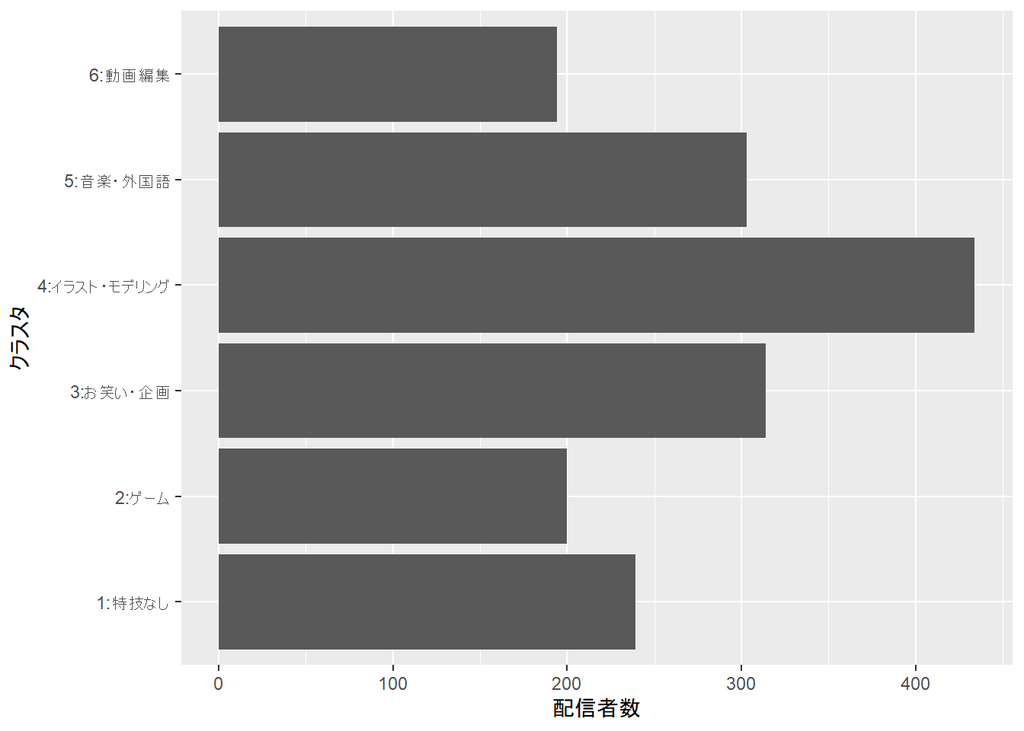

```r
data_customer_cluster %>%
  ggplot(
    aes(
      x = cluster
    )
  ) +
  geom_bar(stat="count") +
  xlab("クラスタ") +
  ylab("配信者数") +
  coord_flip()
```

## 各クラスタごとのチャンネル登録者数

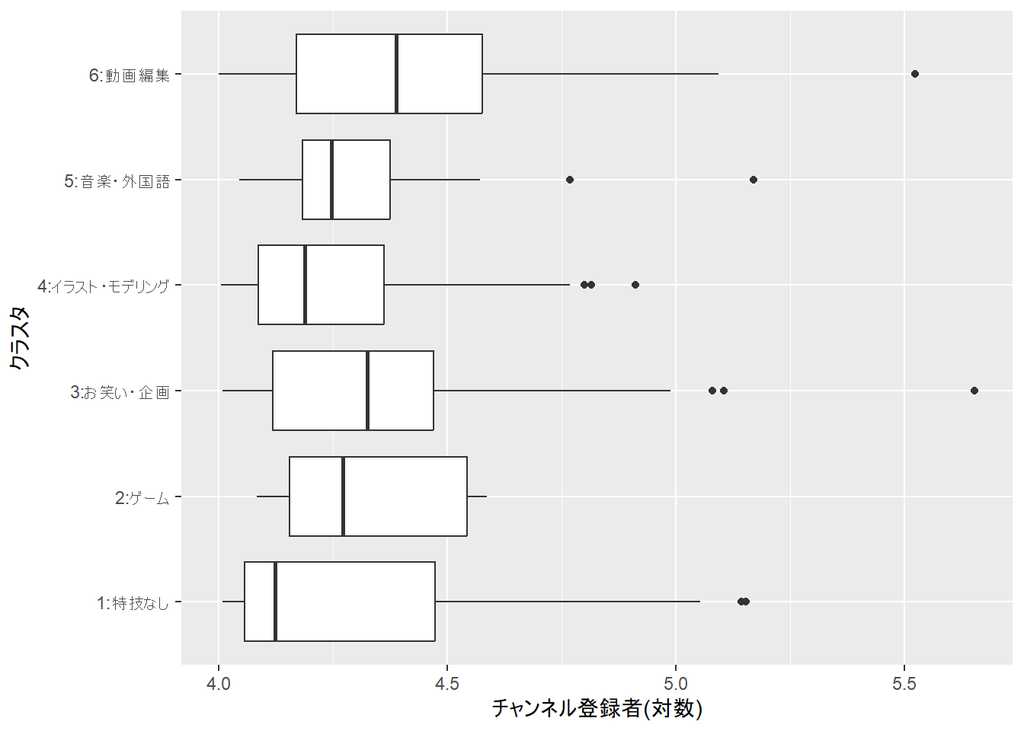

```r
data_livers %>%
  inner_join(data_customer_cluster, by="channelId") %>%
  ggplot(
    aes(
      x = cluster,
      y = subscriberCount %>% log10
    )
  ) +
  geom_boxplot() +
  coord_flip() +
  xlab("クラスタ") +
  ylab("チャンネル登録者(対数)")
```

### 6.1.1 得意なことクラスタとチャンネル登録者は関連するか

```r
data_test <-
  data_livers %>%
  inner_join(data_customer_cluster, by="channelId")

pairwise.t.test(
  data_test$subscriberCount %>% log10,
  data_test$cluster,
  p.adj = "bonf"
)
```

```
##
##  Pairwise comparisons using t tests with pooled SD
##
## data:  data_test$subscriberCount %>% log10 and data_test$cluster
##
##                        1:特技なし 2:ゲーム 3:お笑い・企画
## 2:ゲーム               1          -        -
## 3:お笑い・企画         1          1        -
## 4:イラスト・モデリング 1          1        1
## 5:音楽・外国語         1          1        1
## 6:動画編集             1          1        1
##                        4:イラスト・モデリング 5:音楽・外国語
## 2:ゲーム               -                      -
## 3:お笑い・企画         -                      -
## 4:イラスト・モデリング -                      -
## 5:音楽・外国語         1                      -
## 6:動画編集             1                      1
##
## P value adjustment method: bonferroni
```

- 得意なことがあるからといってチャンネルが伸びるわけではない
  - むしろ得意なことに縛られて配信がつまらなくなることもある？

# 7 ショート動画分析

## 7.1 ショート動画の投稿頻度

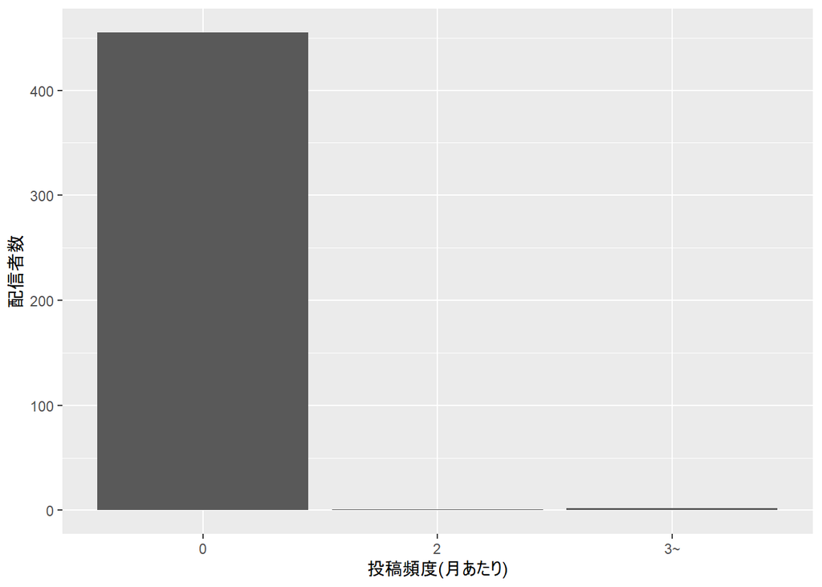

```r
data_short_count<-
  data_videos %>%
  filter(video_type == "short") %>%
  group_by(channelId) %>%
  summarize(n=n())

data_subscriber_and_short <-
  data_livers %>%
  filter(subscriberCount>=100) %>%
  left_join(data_short_count, by="channelId") %>%
  replace_na(list(n=0)) %>%
  mutate(n = ifelse(n>=3,"3~",n))

data_subscriber_and_short %>%
  ggplot(
    aes(
      x = n
    )
  ) +
  geom_bar(stat="count") +
  xlab("投稿頻度(月あたり)") +
  ylab("配信者数")
```

## 7.2 ショート投稿数とチャンネル登録者数

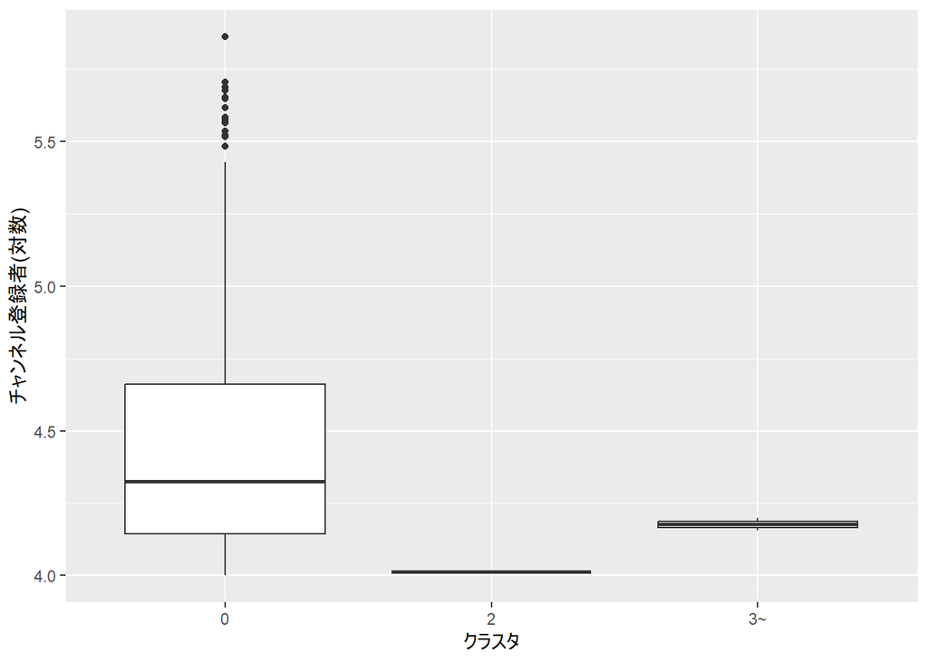

```r
data_subscriber_and_short %>%
  ggplot(
    aes(
      x = n,
      y = subscriberCount %>% log10
    )
  )+
  geom_boxplot() +
  xlab("クラスタ") +
  ylab("チャンネル登録者(対数)")
```

### 7.2.1 ショートの投稿頻度は登録者数に影響を与えるか？

```r
pairwise.t.test(
  data_subscriber_and_short$subscriberCount %>% log10,
  data_subscriber_and_short$n,
  p.adj = "bonf"
)
```

```
##
##  Pairwise comparisons using t tests with pooled SD
##
## data:  data_subscriber_and_short$subscriberCount %>% log10 and data_subscriber_and_short$n
##
##    0    2
## 2  0.86 -
## 3~ 1.00 1.00
##
## P value adjustment method: bonferroni
```

- ショート動画を上げる頻度とチャンネル登録者数は関係ない

## 7.3 バズったショートを定義する

```r
data_short_buzz <-
  data_videos %>%
  filter(video_type == "short") %>%
  inner_join(
    data_livers %>% select(channelId, subscriberCount),
    by="channelId"
  ) %>%
  select(channelId, title, subscriberCount, viewCount) %>%
  filter(viewCount>0) %>%
  mutate(
    log_subscriberCount = subscriberCount %>% log10,
    log_viewCount       = viewCount %>% log10
  )

# 回帰
fit <- lm(log_viewCount ~ log_subscriberCount,data = data_short_buzz)

# 90%予測区間を追加
data_short_buzz <-
  data_short_buzz %>%
  cbind(predict(fit, interval = "prediction", level=0.90))
```

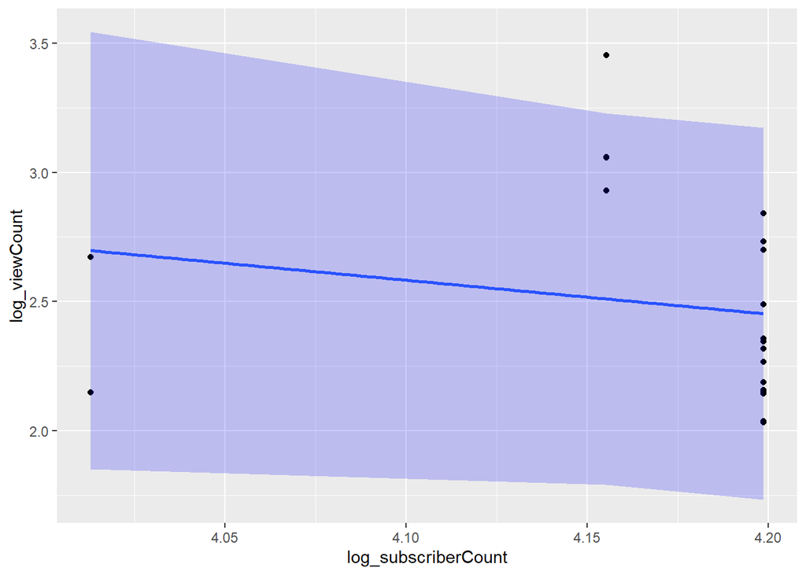

```r
# バズりshortの定義を可視化
data_short_buzz %>%
  ggplot(
    aes(
      x = log_subscriberCount,
      y = log_viewCount
    )
  ) +
  geom_point() +
  geom_smooth(
    method = "lm",
    se = FALSE
  ) +
  geom_ribbon(
    aes(
      ymin = lwr,
      ymax = upr
    ),
    alpha = 0.2,
    fill = 'blue'
  )
```

```r
data_short_buzz_summary <-
  data_short_buzz %>%
  mutate(buzz_count = ifelse(log_viewCount>upr,1,0)) %>%
  group_by(channelId) %>%
  summarize(buzz_count=sum(buzz_count))

data_livers_with_buzz <-
  data_livers %>%
  inner_join(data_short_buzz_summary, by="channelId") %>%
  mutate(buzz_flag = ifelse(buzz_count>0,1,0))

# csvの保存
# data_livers_with_buzz %>% write_csv("../csv/livers_with_buzz.csv")
```

### 7.3.1 バズったShortがあるかどうかと、チャンネル登録者の関係

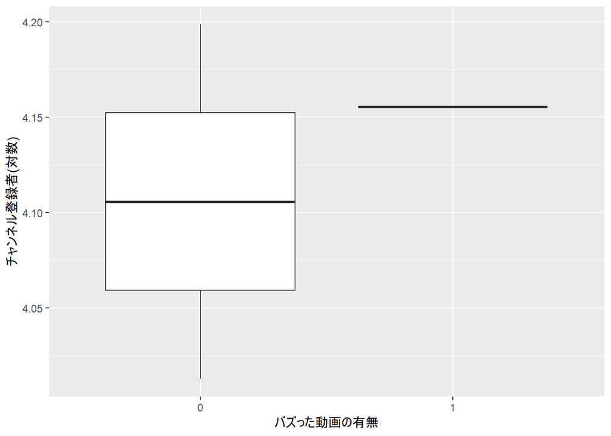

```r
data_livers_with_buzz %>%
  ggplot(
    aes(
      x = buzz_flag %>% as.character,
      y = subscriberCount %>% log10
    )
  )+
  geom_boxplot() +
  xlab("バズった動画の有無") +
  ylab("チャンネル登録者(対数)")
```